# PSPL Process Readme

dwaddell

2022-09-21

# PSPL Site Index Conversion

After the mean site index values have been assigned, there can be species that have missing site index values. We need to fill in missing values where possible using a formalized set of site index conversions.

Create the following tables:

- pspl_site_index_bec
- pspl_site_index_fid
- pspl_site_index_op

The following steps document the order of processing to obtain full site index values for as many species as possible.

## Step 1 all tables: Initial One to one conversions before running formal conversions equations

An initial assessment of species missing site index values shows the majority to be either Spruce or White pine. So some one to one conversions are run.

| Species with missing si | Substitute from |
| --- | --- |
| Sw | Sx |
| Sw | Se |
| Se | Sw |
| Pw | Fd |

These conversions can probably be tuned more to BEC but for now a brute force conversion is run.

## Step 2 all tables: Conversions based on Sindex

SIndex contains a set of conversion equations. These equations were directly translated from C to R.

The following table documents the conversions coefficients.

The conversion equation is of the form:

s1<sub>si</sub> = b<sub>0</sub> + b<sub>1</sub> * s2<sub>si</sub>

| s1 | s2 | b<sub>0</sub> | b<sub>1</sub> |
| --- | --- | --- | --- |
| at | sw | -4.768112309 | 1.253446979 |
| at | sx | -4.768112309 | 1.253446979 |
| at | se | -4.768112309 | 1.253446979 |
| at | bl | -7.216706405 | 1.457496490 |
| at | pl | -7.452123778 | 1.362442366 |
| at | fd | -12.846637615 | 1.700742166 |
| ba | hw | -1.977317550 | 0.986193290 |
| ba | ss | 1.928007878 | 0.789940825 |
| ba | sx | 1.928007878 | 0.789940825 |
| ba | cw | -0.738658778 | 1.033530568 |
| ba | fd | -2.403353051 | 0.886587768 |
| bl | sw | 1.680000000 | 0.860000000 |
| bl | sx | 1.680000000 | 0.860000000 |
| bl | pl | 0.474311930 | 0.917431190 |
| bl | at | 4.951440000 | 0.686108000 |
| bl | fd | -0.221100912 | 0.981651373 |
| bl | lw | -1.360550450 | 0.954128438 |
| bl | sb | -3.497247692 | 1.436697244 |
| cwc | hw | -1.198473280 | 0.95419847 |
| cwc | ba | 0.714694652 | 0.967557249 |
| cwc | ss | 2.580152661 | 0.764312974 |
| cwc | sx | 2.580152661 | 0.764312974 |
| cwc | fd | -1.610687019 | 0.857824425 |
| fdc | hw | 0.480533930 | 1.112347050 |
| fdc | cw | 1.877641825 | 1.165739708 |
| fdc | ba | 2.710789765 | 1.127919909 |
| fdc | ss | 4.885428248 | 0.890989987 |
| fdc | sx | 4.885428248 | 0.890989987 |
| fdi | pl | 0.708411210 | 0.934579440 |
| fdi | bl | 0.225233640 | 1.018691590 |
| fdi | hw | 4.560000000 | 0.887000000 |
| fdi | sw | 4.750000000 | 0.737000000 |
| fdi | sx | 4.750000000 | 0.737000000 |
| fdi | at | 7.553548000 | 0.587978600 |
| fdi | lw | -0.690000000 | 0.983000000 |
| fdi | sb | -3.337383186 | 1.463551403 |
| hwc | cw | 1.256000000 | 1.048000000 |
| hwc | ba | 2.005000000 | 1.014000000 |
| hwc | ss | 3.960000000 | 0.801000000 |
| hwc | sx | 3.960000000 | 0.801000000 |
| hwc | fd | -0.432000000 | 0.89900000 |
| hwi | fd | -5.140924460 | 1.127395720 |
| hwi | sw | 0.214205210 | 0.830890646 |
| hwi | sx | 0.214205210 | 0.830890646 |
| hwi | pl | -4.342264694 | 1.053640861 |
| hwi | lw | -5.918827507 | 1.108229993 |
| lw | fd | 0.701932860 | 1.017294000 |
| lw | bl | 1.425961536 | 1.048076921 |
| lw | pl | 1.923076920 | 0.961538460 |
| lw | sw | 3.817307686 | 0.884615383 |
| lw | sx | 3.817307686 | 0.884615383 |
| lw | hw | 5.340793500 | 0.902339778 |
| lw | sb | -2.239423073 | 1.505769228 |
| pl | sw | 1.970000000 | 0.920000000 |
| pl | sx | 1.970000000 | 0.920000000 |
| pl | hw | 4.121200000 | 0.949090000 |
| pl | at | 5.469680000 | 0.733976000 |
| pl | bl | -0.517000000 | 1.090000000 |
| pl | fd | -0.758000000 | 1.070000000 |
| pl | lw | -2.000000000 | 1.040000000 |
| pl | sb | -4.329000000 | 1.566000000 |
| sb | pl | 2.764367820 | 0.638569600 |
| sb | lw | 1.487228620 | 0.664112384 |
| sb | fd | 2.280332063 | 0.683269472 |
| sb | bl | 2.434227337 | 0.696040864 |
| sb | sw | 4.022349932 | 0.587484032 |
| sb | sx | 4.022349932 | 0.587484032 |
| ss | hw | -4.943820220 | 1.248439450 |
| ss | ba | -2.440699123 | 1.265917602 |
| ss | cw | -3.375780271 | 1.308364544 |
| ss | fd | -5.483146062 | 1.122347066 |
| sw | pl | -2.141304350 | 1.086956520 |
| sw | at | 3.804000000 | 0.797800000 |
| sw | hw | -0.257801914 | 1.203527813 |
| sw | bl | -1.953488370 | 1.162790700 |
| sw | lw | -4.315217390 | 1.130434781 |
| sw | fd | -6.445047490 | 1.356852100 |
| sw | sb | -6.846739125 | 1.702173910 |

## Step 3 all tables: Additional one to one conversions

After running the SIndex conversions there are still species missing site index values. It has been recommended that the SIndex conversion equations only be run once (Gord Night). Following on this, we are the limited to a direct conversion from alternative species. The following species conversion are therefore being used.

### Alder

George Harper has proposed that using the Fir site index may be giving a siteindex that is too high.

He suggested using:

For Coastal BEC and subzones: ds, db, xm

dr_si = fd_si * 0.55

For all other subzones:

dr_si = fd_si * 0.73

Sharad Baral produced the following height comparison:

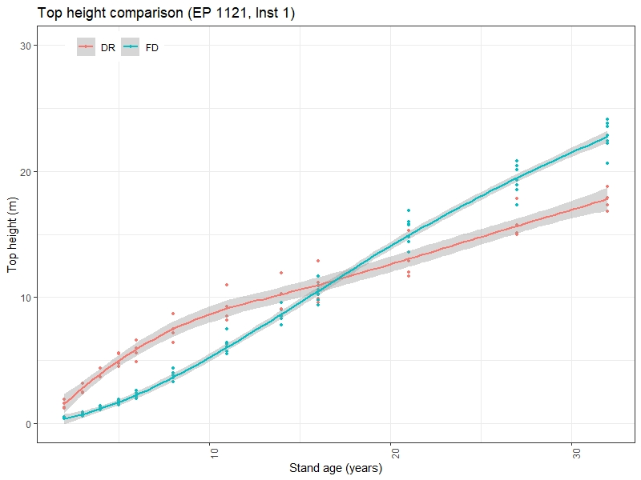

### Interior Cwi

For missing values, substitute: Sw

### Py

Where Py is in the SBS, can substitute Fd site index.  
Augmented this to substitute Fd site index anywhere Py site index is missing.

### Balsam

Ba / Bg / Bl interchangeable

### Ss

For missing values, substitute: Pw

### Larch

Lt / Lw interchangeable  
___

### Hemlock

Hm /Hw interchangeable  
___

### Pa

Pa / Pl interchangeable

### Spruce again

| Species with missing si | Substitute from |
| --- | --- |
| Sw | Sx |
| Sw | Se |
| Se | Sw |
| Ss | Sx |
| Ss | Pw |
| Ss | Fd |

These spruce conversions are complicated by the use of Sx in identifying hybrid spruce. A simple use Se if ESSF and otheriwse Sw for the interior doesn’t work as I sometimes get Se planted outside the ESSF. Then everything gets confused.

### Discussion

At this point, I am NOT using BEC breakdowns to subset areas of application of the one to one conversions. I am bluntly forcing, to check for broad level impacts. In particular, the use of Sx as a species is causing problems in general. To tune this conversion, I should probably add the appropriate BEC zones for application. Then do a cross check to see how this affects performance of the conversions.

I can easily add Coast Interior splits for these conversions. For Coast Interior definition I use:

- Coast = CDF, CWH, MH
- Interior = everything else

## Step 4: Derive BEC based site index

### BEC CrossWalk substitution

The table of mean bec based site index values has all the above conversions applied to it. In addition, since SWB has no PEM/TEM nor a biophysical model there will be no site index values. Instead, the SWB will use a BEC CrossWalk substitution from BWBS dk.

| Bec with missing si | CrossWalk from |
| --- | --- |
| SWB mk,mks,un,vk | BWBS dk |

This was suggested via conversations with either Will Will MacKenzie or Deb MacKillop. (I will confirm)

This gives us a table of BEC aggregates for each BEC zone and subzone.

## Step 5: Derive Opening level site index

The table of mean opening based site index values has all the base site index conversions applied.

### Use BEC aggregates

In addition, the BEC aggregate site index values are used where there are missing values.

## Step 6: Derive Feature id based site index

### Replace site index from opening

Since the MSYT process is opening based, the feature_id based site index values are overwritten where there is an opening and the opening site index values derived above are substituted.

### Use BEC aggregates

Apply BEC aggregate substitutions for missing values